# Multiple `geom_raster()` with different fill scales with `purrr` and `patchwork`

It’s often useful to show small multiples of a `geom_raster()`. With other `geom_*`. While this can be done with `facet_wrap()` or `facet_grid()`, we canot set `scales = "free"` for the fill. If we need to have multiple fill scales we need another approach: Enter `purrr` to map from a nested tibbles of data to a list of plots that can be arranged with patcheork. Here is a worked example using images of handwritten digits from the MNIST dataset

### Load required libraries

We’ll get the mnist data from the `snedata` package, so install that if needed. We’ll use the `tidyverse` packages along with `patchwork` for stitching the plots together and `janitor` for cleaning up some colnames.

```r
library(tidyverse)
#remotes::install_github("jlmelville/snedata")
library(snedata)
library(patchwork)
library(janitor)
library(scales)
```

### Read and munge data

Download `mnist from snedata`, select 1 image from each of the labels (0 to 9), and put in a long format with x and y coordinates for plotting.

| label | id | pixel | intensity | x | y |
| --- | --- | --- | --- | --- | --- |
| 0 | 1 | px1 | 0 | 1 | 1 |
| 0 | 1 | px2 | 0 | 2 | 1 |
| 0 | 1 | px3 | 0 | 3 | 1 |
| 0 | 1 | px4 | 0 | 4 | 1 |
| 0 | 1 | px5 | 0 | 5 | 1 |
| 0 | 1 | px6 | 0 | 6 | 1 |

### Faceting

The obvious approach to plot these 10 representative images would be to use `facet_wrap()`. This works well when all images have the same fill range and distribution, here between 0 and 255.

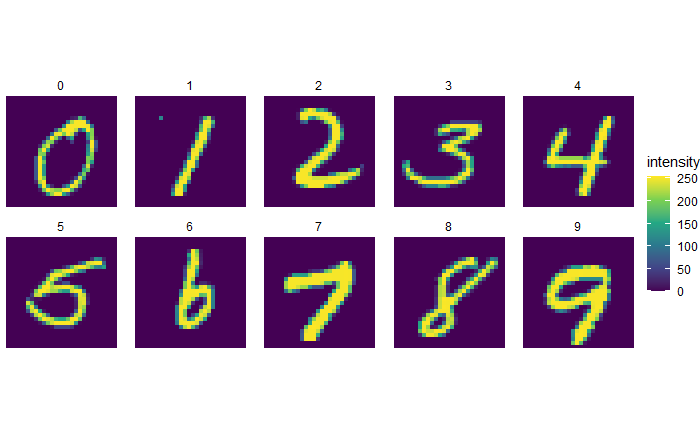

```r
mnist_tidy %>%
  ggplot(aes(x, y, fill = intensity)) +
  geom_raster() +
  scale_y_reverse() +
  coord_equal() +
  scale_fill_viridis_c() +
  theme_void() +
  facet_wrap(~label, ncol = 5)
```

### But what if our data isn’t all on the same intensity scale?

Lets simulate this by scaling the intensity - The image of zero is now scaled between 0 and 255, and the image of nine is scaled beteween 0 and 2550. When we plot this with facet_wrap the lower numbers, with lower intensities are more difficult to see.

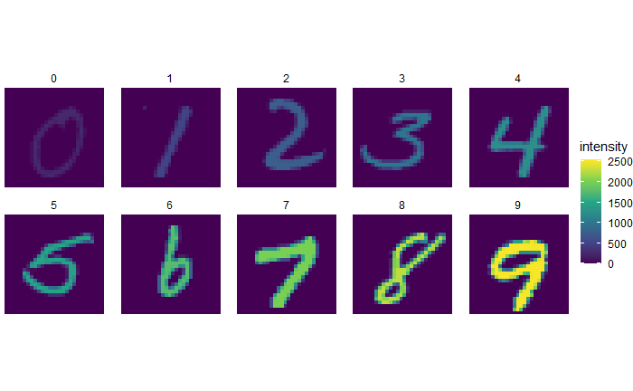

### Saturate the intensity data

We could adjust `scale_fill` to saturate high intensity pixels. While this allows us to see the low intensity digits more clearly, it blows out detail in the higher intensity digits.

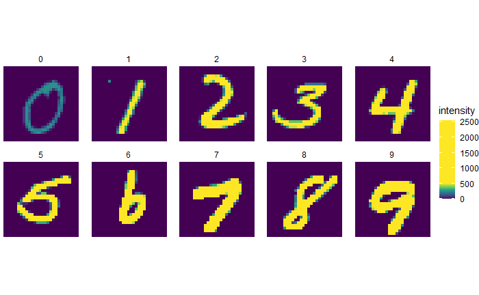

```r
mnist_scaled %>%
  ggplot(aes(x, y, fill = intensity)) +
  geom_raster() +
  scale_y_reverse() +
  coord_equal() +
  scale_fill_viridis_c(values = c(0, 0.2),
                       na.value = viridis::viridis(2)[2]) +
  theme_void() +
  facet_wrap(~label, ncol = 5)
```

### Rescale the data

We could just rescale the data between 0 and 1 within each image, but this looses information about each image’s overall intensity

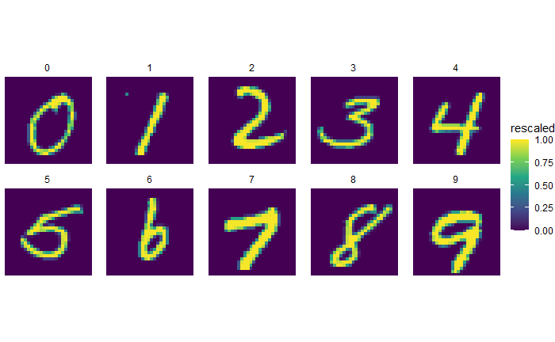

```r
mnist_scaled %>% group_by(label, id) %>%
  mutate(rescaled = scales::rescale(intensity, c(0,1))) %>%
  ggplot(aes(x, y, fill = rescaled)) +
  geom_raster() +
  scale_y_reverse() +
  coord_equal() +
  scale_fill_viridis_c() +
  theme_void() +
  facet_wrap(~label, ncol = 5)
```

### What about a seperate fill scale per plot using `purrr` and `patchwork`.

In order to have a seperate scale per image we need to plot them seperately. We can do this efficiently by nesting the data, and applying a plotting function with purrr::map. We can then pull a list of plots that can be stitched together with `patchwork`.

[figure not shown]

```r
# Plotting function
plot_mnist <- function(data, label){
  data %>%
    ggplot(aes(x, y, fill = intensity)) +
    geom_raster() +                                               # set the geom
    scale_y_reverse() +                                           # invert the y axis
    coord_equal() +                                               # set aspect ratio of each pixel
    scale_fill_viridis_c(breaks = scales::pretty_breaks(n = 3)) + # set scale viridis and reduce break number
    theme_void() +                                                # set the theme
    labs(subtitle = label) +                                      # add label as a subtitle
    theme(legend.title = element_blank(),                         # remove legend title
          legend.key.width = unit(8,"pt"),                        # make scale narrower
          legend.key.height = unit(10, "pt"),                     # make scale shorter
          legend.margin = margin(0,10,0,-5, unit = "pt"))         # push scale sligtly closer to the plot
}

# Map and stitch the plots
mnist_scaled %>%
  group_nest(label, id) %>%                                       # nest the data
  mutate(plot = map2(data, label,plot_mnist)) %>%                 # make a plot from the data in each nested tibble
  pull(plot) %>%                                                  # pull the list of plots
  wrap_plots(ncol = 5)                                            # stitch these plots together
```

We can extend this by adding variables to the plotting fucntion - here we reverse the scale for odd numbers. For more than 2 variables in the plotting function, you’ll need to use `pmap`.

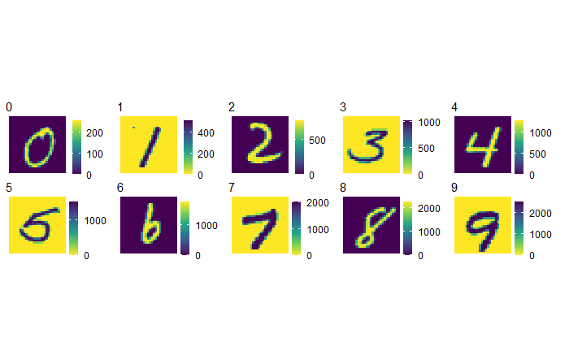

```r
plot_mnist_v2 <- plot_mnist <- function(data, label, direction){
  data %>%
    ggplot(aes(x, y, fill = intensity)) +
    geom_raster() +                                               # set the geom
    scale_y_reverse() +                                           # invert the y axis
    coord_equal() +                                               # set aspect ratio of each pixel
    scale_fill_viridis_c(direction = {{direction}},
                         breaks = scales::pretty_breaks(n = 2)) +
    theme_void() +                                                # set the theme
    labs(subtitle = label) +                                      # add label as a subtitle
    theme(legend.title = element_blank(),                         # remove legend title
          legend.key.width = unit(8,"pt"),                        # make scale narrower
          legend.key.height = unit(10, "pt"),                     # make scale shorter
          legend.margin = margin(0,10,0,-5, unit = "pt"))         # push scale sligtly closer to the plot
}

mnist_scaled %>%
  group_nest(label, id) %>%
  mutate(direction = ifelse(label %in% c(0,2,4,6,8), 1, -1)) %>%
  mutate(plot = pmap(list(data, label, direction), plot_mnist_v2)) %>%
  pull(plot) %>%
  wrap_plots(ncol = 5)
```